# mrgsolve

Shen Cheng

2021-07-01

# 1. `mrgsolve` in general

- an `R` package for simulation from hierarchical, ordinary differential equation (ODE) based models typically employed in drug development.
  - free, open-source software
  - utilizes an ODE-solver from `ODEPACK` (freely-available in the public domain)
- Language
  - Models written in `C++` inside model specification format
  - Simulation workflow in `R`
  - Integrate certain `NONMEM` functionality so easier for `NONMEM` users to get involved
    - `F`, `ALAG`, `SS`, `AMT`,`CMT`, etc

# 2. Installation

- [The trickest part](https://github.com/metrumresearchgroup/mrgsolve)
  - `install.packages("mrgsolve")`
  - `remotes::install_github("metrumresearchgroup/mrgsolve@dev")`
  - `C++` complier
  - `FORTRAN` complier
- [installation guide](https://github.com/metrumresearchgroup/mrgsolve/wiki/mrgsolve-Installation)
- Prerequists:
  - `R`: https://cran.r-project.org/
    - Currently `R` >= 3.1.2 is required
  - Seriously consider running in `Rstudio` if possible. This is not required but is recommended.
  - Compilers: `C++` and `gfortran`

# 3. Simulation with `mrgsolve`

Two major components:

- Model specification file written in `C++`
- Simulation specification file written in `R`
- We are able to combine two files into one as a single `R` script or `R markdown` file

## 3.1 Model specification file

- The model file for `mrgsolve` is written in `C++` syntax and saved as a `.cpp` file.
- Alternatively, the model can be written in `C++` syntax and saved as a `R` object

```r
one_comp_mod <- '

[set] delta = 0.01, end = 50 //set options for simulations

[PROB]
// $PROB
 - author: Shen Cheng
 - date: `r Sys.Date()`
 - comments: this is a demonstration
 - one compartment model + first order absportion
 - random effects added on `CL` and `VC` as exponential distributions
 - proportional error model
 - model covariate: SEX ~ CL

$PARAM
TVCL = 1, TVVC = 20, TVKA = 1, SEXCL=0.5, SEX=0

$CMT  @annotated
// similar to $MODEL in NONMEM
// if @annotated is not used, simply declare compartment names with a space

DEPOT  : Depot compartment (mass)
CENT   : Central compartment (mass)

$MAIN
// similar to $PK block in NONMEM

double CL   = TVCL*exp(ETA(1))*pow(SEXCL, SEX); //power function in C++ witten as pow(,), SEXCL^SEX
double VC   = TVVC*exp(ETA(2))                ; // "double" means defining the data structure as double
double KA   = TVKA                            ; // ";" is required at the end of each defined variable


$GLOBAL
// declare variables you want to either use further in computation
// OR derive variables you want calculated from computations

// bool cure = FALSE; // declaring variables needs ";" at the end
// double CL, VC, KA; // declaring variables so no "double" is need in $MAIN
#define CP (CENT/VC)  // # define does not require ";"

//[PREMABLE]
// similar to $GLOBAL to some extent
// However, unlike $MAIN $TABLE and $ODE, $PREMABLE only call once during the simulation

$OMEGA @block
// @block generates a block matrix with the formulation (1,1), (1,2), (2,2)....
// @correlation will specify values to be corrleations instead as variances

0.1 0.02 0.3

$SIGMA
// epsilon variances go here

0.01

$ODE
//similar to $DES in NONMEM
//differential equations go here

dxdt_DEPOT = -KA*DEPOT;
dxdt_CENT  = KA*DEPOT - CL*CP;

$TABLE
//another block could be used for defining secondary parameters

double DV = CP * (1 + EPS(1));

$CAPTURE
//This is a block to identify variables that should be captured in the simulated output

CP, DV

'
```

## 3.2 Simulation specification file

### 3.2.1 Read model in R mrgsolve

```r
library(mrgsolve)
library(tidyverse) #simulation with mrgsolve is normally integrated in a tidyverse workflow (lots of use of " %>% ")
library(ggpubr) #package for combining plots
```

- We can read in our model from a saved `.cpp` file using `mread`  
  -`mread("file name", "path")`

```r
mod <- mread("one_comp_mod", "/Users/shencheng/Documents/GitHub/SummerSession2021/Session2_Simulations")
```

```
## Building one_comp_mod ... done.
```

```r
# setwd("/Users/shencheng/Documents/GitHub/SummerSession2021/Session2_Simulations")
# mod <- mread("one_comp_mod")
```

- or we can read in our model from a `R` object using `mcode` -`mcode("model name", code)`

```r
mod <- mcode("one_comp_mod", one_comp_mod)
```

### 3.2.2 Model check

```r
mod        #model check
```

```
##
##
## -------------  source: one_comp_mod.cpp  -------------
##
##   project: /Users/shencheng...2_Simulations
##   shared object: one_comp_mod-so-8e2854bfc393
##
##   time:          start: 0 end: 50 delta: 0.01
##                  add: <none>
##
##   compartments:  DEPOT CENT [2]
##   parameters:    TVCL TVVC TVKA SEXCL SEX [5]
##   captures:      CP DV [2]
##   omega:         2x2
##   sigma:         1x1
##
##   solver:        atol: 1e-08 rtol: 1e-08 maxsteps: 20k
## ------------------------------------------------------
```

```r
param(mod) #check model parameters
```

```
##
##  Model parameters (N=5):
##  name  value . name value
##  SEX   0     | TVKA 1
##  SEXCL 0.5   | TVVC 20
##  TVCL  1     | .    .
```

```r
init(mod)  #check initial conditions of model compartments
```

```
##
##  Model initial conditions (N=2):
##  name       value . name        value
##  CENT (2)   0     | DEPOT (1)   0
```

```r
omat(mod)  #check omega matrix
```

```
## $...
##     [,1] [,2]
## 1:  0.10 0.02
## 2:  0.02 0.30
```

```r
smat(mod)  #check sigma matrix
```

```
## $...
##     [,1]
## 1:  0.01
```

### 3.2.3 Simulation workflow

- A commonly used simulation workflow could be something like the codes shown below

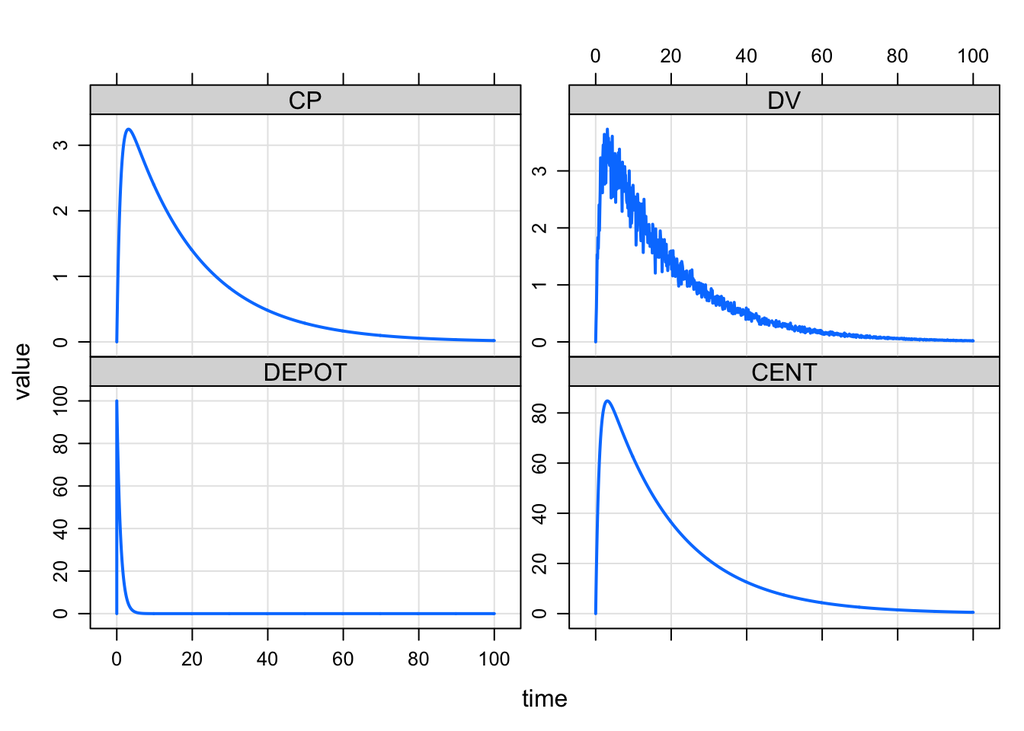

```r
#an illustration of the common workflow of simulation using mrgsolve
mod %>%                           #start with model object
  #req(CP, DV) %>%                 #request specific model output
  ev(amt=100, cmt=1, time=0) %>%  #specify the events
  mrgsim(end=100, delta=0.1) %>%  #starts simulations, end and delta can be specified in the model file or within mrgsim
  plot()                          #a quick simulation check
```

```r
  #plot(CP~time)                  #only plot CP vs time
```

- `nid` within `mrgsim` allows us to quickly do a population simulation

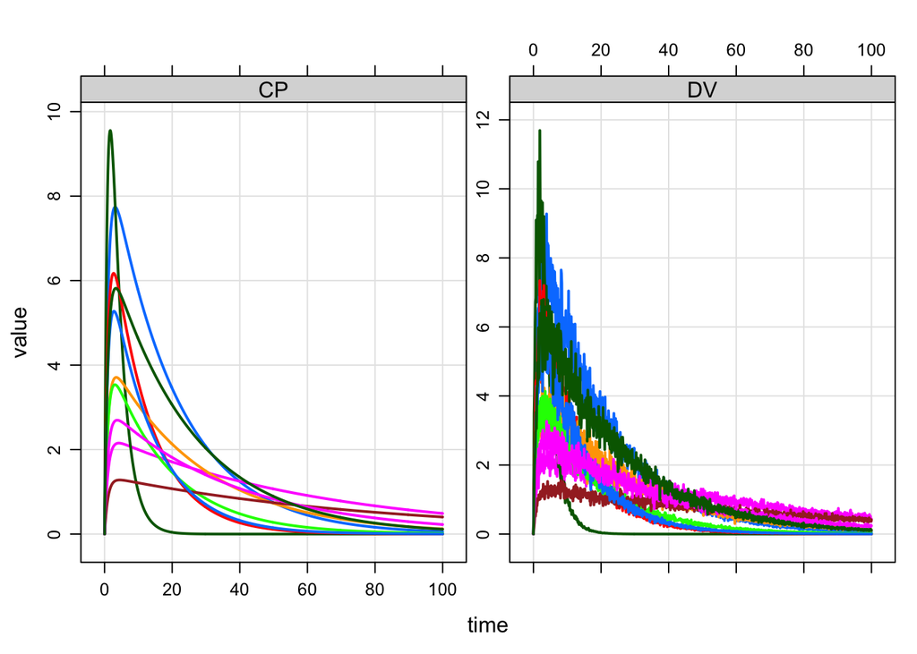

```r
mod %>%
  req(CP, DV) %>%
  ev(amt=100, cmt=1, time=0) %>%
  mrgsim(end=100, delta=0.1, nid=10) %>% #nid: specify number of subjects we want to simulate
  plot()
```

- Simulation with a dataset using `data_set()` could be very useful
  - a dataset normally includes both interventions and populations

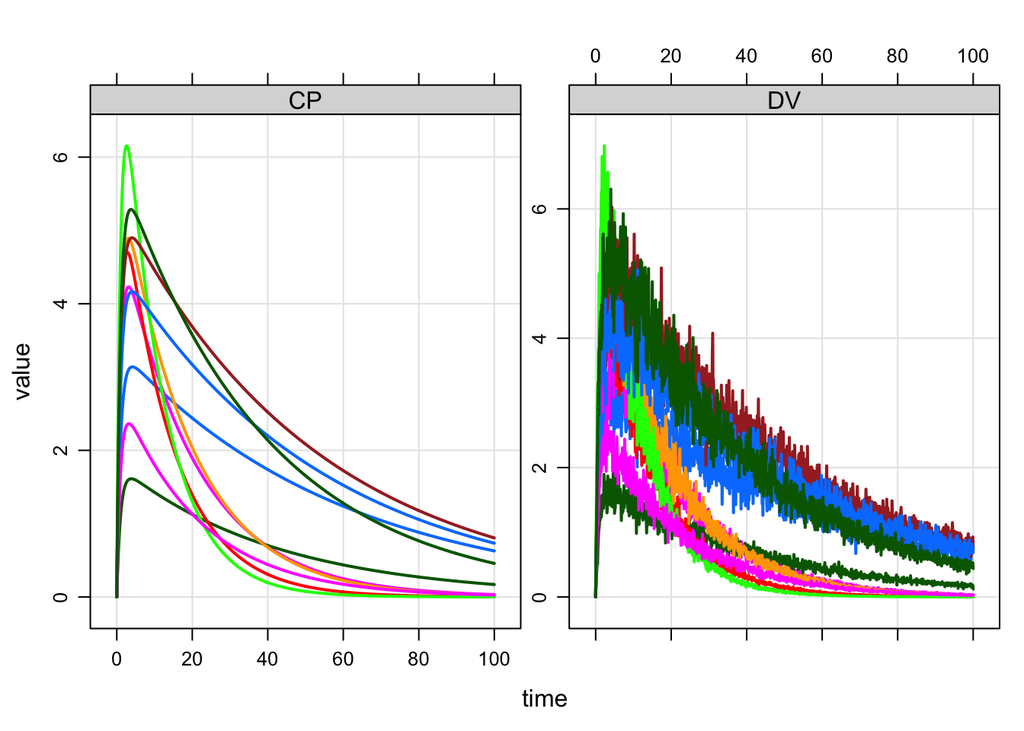

```r
data <- data.frame(ID = seq(1, 10), #simulate 10 subjects
                   amt = 100, #amt specify doses
                   cmt = 1, #specify dosing compartment
                   time = 0, #specify dosing time
                   evid = 1, #this is a doing event
                   SEX = sample(c(0,1), replace=TRUE, size=10)) #model covariate SEX, 0 means female, 1 means male
                                                                #sample(), take 10 samples from c(0,1) with replacement

mod %>%
  req(CP, DV) %>%
  data_set(data) %>%   #simulate from a dataset, a dataset typically include event and population
  mrgsim(end=100, delta=0.1) %>%
  plot()
```

- `plot()` after `mrgsim()` allows a quick check of the model output
- Plotting with `ggplot()` allows more flexiblity and higher quality

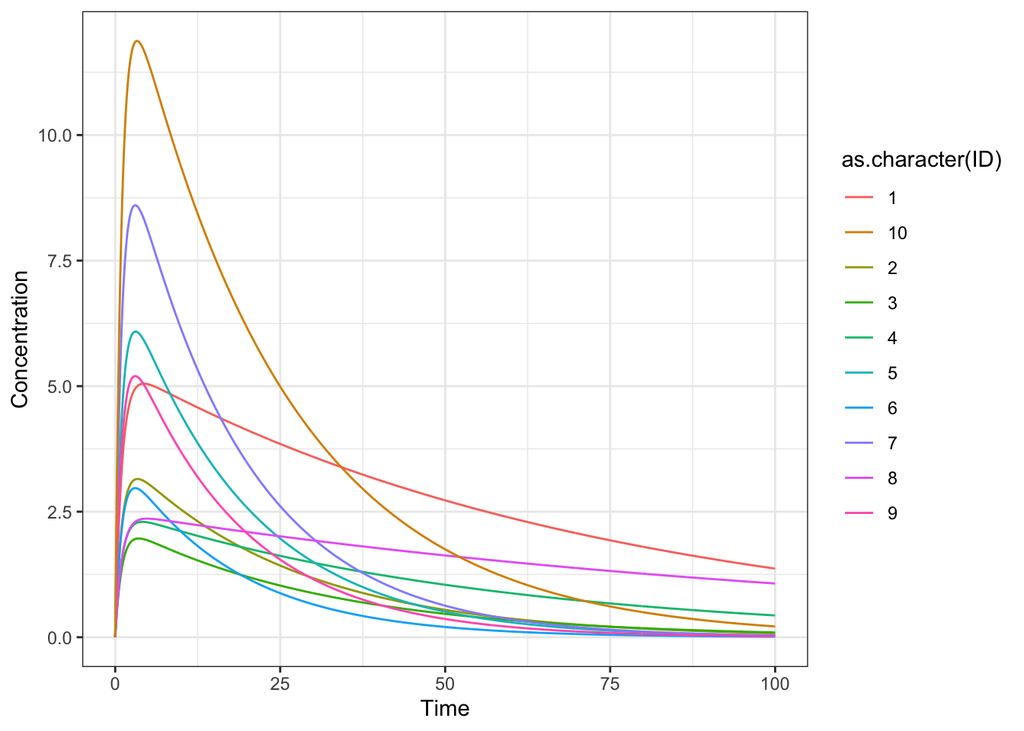

```r
sim <-
  mod %>%
  req(CP, DV) %>%
  data_set(data) %>%
  mrgsim(end=100, delta=0.1) %>%
  as.data.frame()  #turn model simulation into a data frame

sim %>%
  ggplot(aes(x=time, y=CP, group=ID, color=as.character(ID)))+
  geom_line()+
  xlab("Time")+
  ylab("Concentration")+
  theme_bw()  #plot with ggplot
```

- Sometimes we may want to simulate without random effects.
- `zero_re()` sets all random effects to 0 when model compile in

```r
mod <-
  mread("one_comp_mod", "/Users/shencheng/Documents/GitHub/SummerSession2021/Session2_Simulations") %>%
  zero_re() # sets random effects to 0 when model compile in
```

```
## Building one_comp_mod ... done.
```

```r
omat(mod)  #check model omega matrix
```

```
## $...
##     [,1] [,2]
## 1:     0    0
## 2:     0    0
```

```r
smat(mod)  #check model sigma matrix
```

```
## $...
##     [,1]
## 1:     0
```

- Let's simulate 10 subjects and check their difference

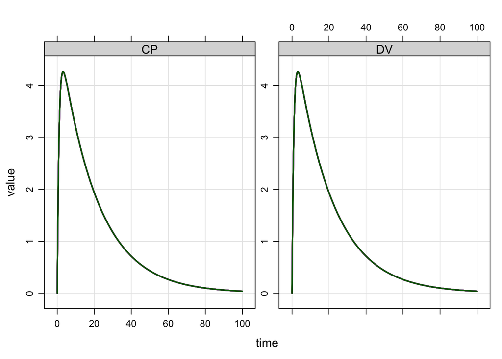

```r
mod %>%
  req(CP, DV) %>%
  ev(amt=100, cmt=1, time=0) %>%
  mrgsim(end=100, delta=0.1, nid=10) %>%
  plot()
```

- Check sex effect on CL

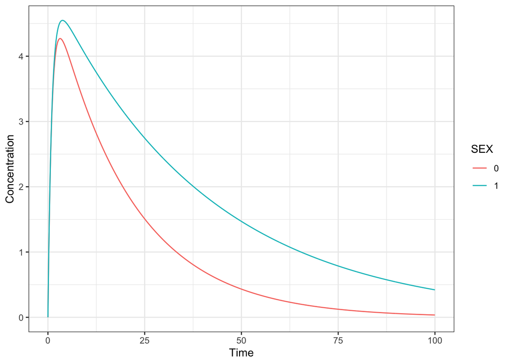

```r
data_pop <-
  data.frame(ID = seq(1, 2), #simulate 2 subjects
             amt = 100, #amt specify doses
             cmt = 1, #specify dosing compartment
             time = 0, #specify dosing time
             evid = 1, #this is a doing event
             SEX = c(0,1)) #model covariate SEX, 0 means female, 1 means male

sim_pop <-
  mod %>%
  req(CP, DV) %>%
  data_set(data_pop) %>%
  mrgsim(end=100, delta=0.1) %>%
  as.data.frame()  #turn model simulation into a data frame

sim_pop %>%
  mutate(SEX = if_else(ID == 1, 0, 1)) %>%
  mutate(SEX = as.character(SEX)) %>%
  ggplot(aes(x=time, y=CP, group=ID, color=SEX))+
  geom_line()+
  xlab("Time")+
  ylab("Concentration")+
  theme_bw()
```

### 3.2.4 Interventions

- `ev()` or `data_set()` are commonly used for specify interventions. Here're the things that can be recognized as interventions in either `ev()` or `data_set()`:
  - `time` event time
  - `cmt` Event compartment
  - `amt` Dose amount
  - `ii` Inter-dose interval
  - `addl` Additional doses to administer
  - `rate` Infusion rate
    - rate = 0 is bolus
    - rate > 0 is zero order infusion (`evid` 1)
  - `ss` Set to 1 to advance to steady state
  - `evid` Event id.
    - `evid` 0 is for "observations"
    - `evid` 1 is for "dose"
    - `evid` 2 is for "other"
    - `evid` 3 is for compartment reset
    - `evid` 4 is reset and dose
  - `ID` Subject ID (use multiple ids - ID = 1:10)

*`ev()` can easily combine of interventions

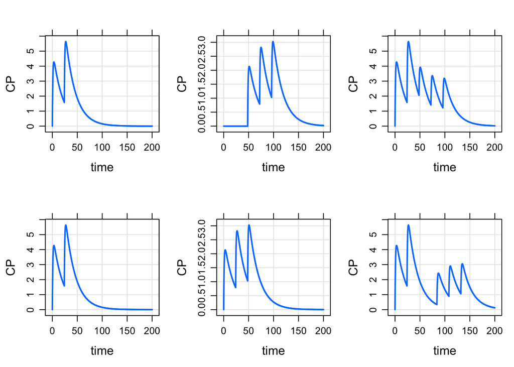

```r
e1 = ev(amt=100, time=0, ii=24, addl=1)
e2 = ev(amt=50, time=48, ii=24, addl=2)
e3 = c(e1, e2)  #combine e1 and e2

e4 = ev(amt=100, ii=24, addl=1)
e5 = ev(amt=50, ii=24, addl=2)
e6 = seq(e4, wait=36, e5)  #combine e4 and e5 in sequence
                           #`wait=` sets intervals between interventions

p1 <- mod %>% ev(e1) %>% mrgsim(delta=0.01, end=200) %>% plot(CP ~ time)
p2 <- mod %>% ev(e2) %>% mrgsim(delta=0.01, end=200) %>% plot(CP ~ time)
p3 <- mod %>% ev(e3) %>% mrgsim(delta=0.01, end=200) %>% plot(CP ~ time)
p4 <- mod %>% ev(e4) %>% mrgsim(delta=0.01, end=200) %>% plot(CP ~ time)
p5 <- mod %>% ev(e5) %>% mrgsim(delta=0.01, end=200) %>% plot(CP ~ time)
p6 <- mod %>% ev(e6) %>% mrgsim(delta=0.01, end=200) %>% plot(CP ~ time)

ggarrange(p1, p2, p3, p4, p5, p6, ncol=3, nrow=2)
```

- `expand_ev()` facilate the simulations of different dosing regimens

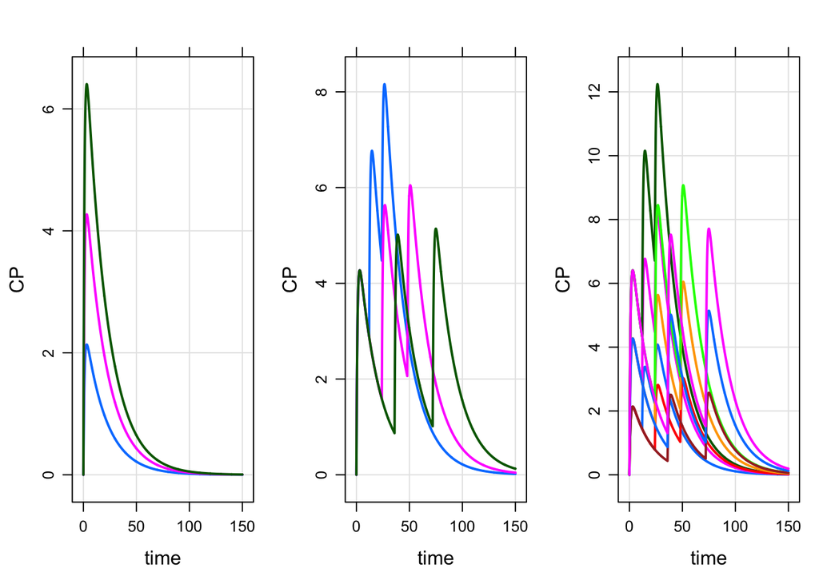

```r
data_ev1 <- expand.ev(amt=c(50, 100, 150), time=0)
data_ev2 <- expand.ev(amt=100, ii=c(12, 24, 36), addl=2)
data_ev3 <- expand.ev(amt=c(50, 100, 150), ii=c(12, 24, 36), addl=2) #`expand_ev` on multiple factors sets all combinations on test conditions

p7 <- mod %>% data_set(data_ev1) %>% mrgsim(end=150, delta=0.1) %>% plot(CP~ time)
p8 <- mod %>% data_set(data_ev2) %>% mrgsim(end=150, delta=0.1) %>% plot(CP~ time)
p9 <- mod %>% data_set(data_ev3) %>% mrgsim(end=150, delta=0.1) %>% plot(CP~ time)

ggarrange(p7, p8, p9, ncol=3)
```

### 3.2.5 Sensitivity analysis with `mrgsolve`

- Sensitivity analysis is commonly used for assessing the impact of the parameters on model predictions.
- `mrgsolve` enables multiple ways to conduct sensitivity analysis
  - `expand_idata()` and `idata_set()`
  - `knobs()`

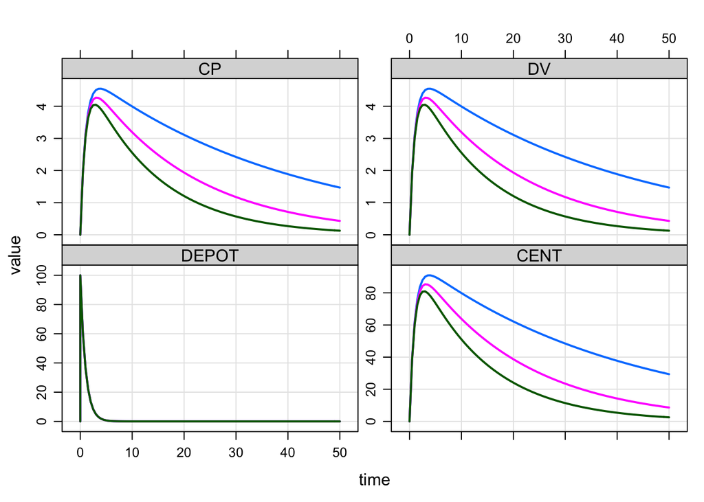

```r
idata <- expand.idata(TVCL = c(0.5, 1, 1.5))

mod %>%
  idata_set(idata) %>%
  ev(amt=100, cmt=1, time=0) %>%
  mrgsim(end=50, delta=0.5) %>%
  plot()
```

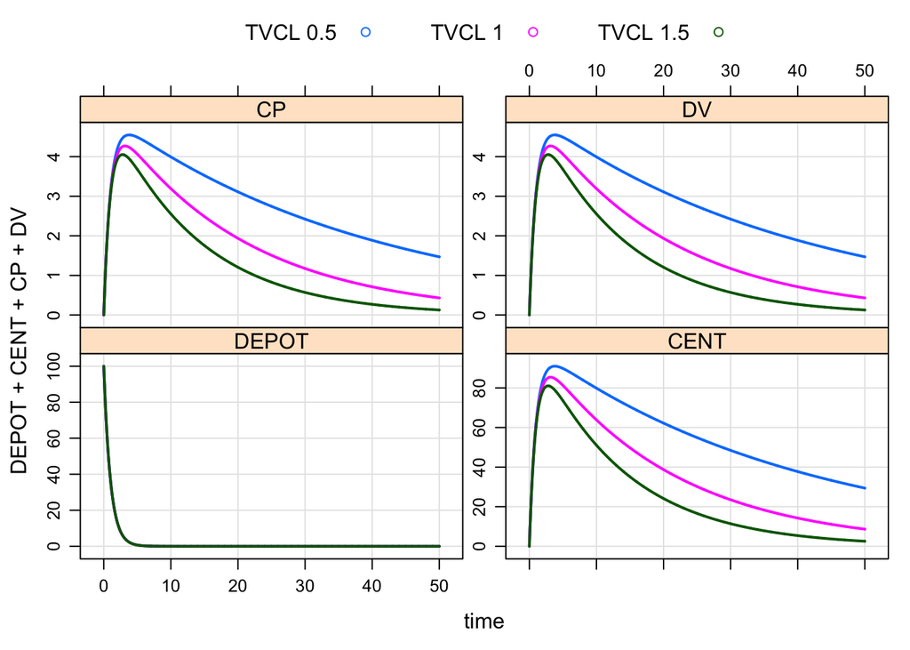

```r
mod %>%
  ev(amt=100, cmt=1, time=0) %>%
  knobs(TVCL = c(0.5, 1, 1.5)) %>%  #no `mrgsim` is needed if `knobs` is used
  plot()
```

### 3.2.6 population simulation with `mrgsolve`

- Let's first read back in our model with random effects

```r
mod <- mread("one_comp_mod", "/Users/shencheng/Documents/GitHub/SummerSession2021/Session2_Simulations")
```

```
## Building one_comp_mod ... done.
```

```r
omat(mod)  #check model omega matrix
```

```
## $...
##     [,1] [,2]
## 1:  0.10 0.02
## 2:  0.02 0.30
```

```r
smat(mod)  #check model sigma matrix
```

```
## $...
##     [,1]
## 1:  0.01
```

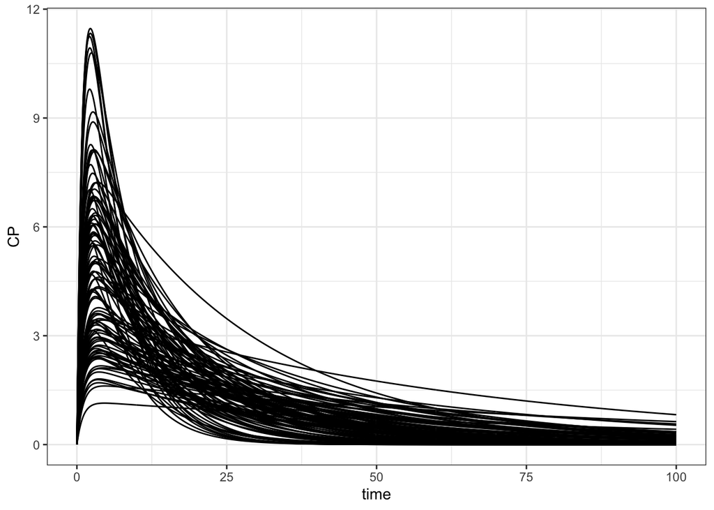

```r
sim1 <-
  mod %>%
  ev(amt=100, cmt=1, time=0) %>%
  mrgsim(end=100, delta=0.1, nid=100, obsonly=TRUE) %>% #`obsonly` will carryout only observation records (evid=0)
  as.data.frame()

sim1 %>%
  ggplot(aes(x=time, y=CP, group=ID))+
  geom_line()+
  theme_bw()
```

- With functionalities in `tidyverse`, we can calculate summary statistics and then plot.

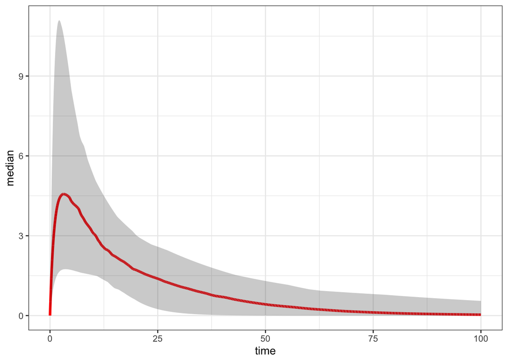

```r
sim1 %>%
  group_by(time) %>%
  mutate(median = median(CP),
         upper = quantile(CP, 0.975),
         lower = quantile(CP, 0.025)) %>%
  ggplot()+
  geom_line(aes(x=time, y=median), color="red", size=1.2)+
  geom_ribbon(aes(x=time, ymin=lower, ymax=upper), fill="gray20", alpha=0.25)+
  theme_bw()
```

### 3.2.7 update model parameters

- Model parameters can be updated on the fly
- Use `param()` for updating parameters in [PARAM]

```r
param(mod)
```

```
##
##  Model parameters (N=5):
##  name  value . name value
##  SEX   0     | TVKA 1
##  SEXCL 0.5   | TVVC 20
##  TVCL  1     | .    .
```

```r
mod2 <- mod %>% param(TVVC = 30)
param(mod2)
```

```
##
##  Model parameters (N=5):
##  name  value . name value
##  SEX   0     | TVKA 1
##  SEXCL 0.5   | TVVC 30
##  TVCL  1     | .    .
```

- Use `omat` to update parameters in [OMEGA]

```r
omat(mod)
```

```
## $...
##     [,1] [,2]
## 1:  0.10 0.02
## 2:  0.02 0.30
```

```r
mod3 <- mod %>% omat(bmat(0.1, 0.002, 0.3)) #bmat used for updating a block matrix
omat(mod3)
```

```
## $...
##      [,1]  [,2]
## 1:  0.100 0.002
## 2:  0.002 0.300
```

- Use `smat` to update parameters in [SIGMA]

```r
smat(mod)
```

```
## $...
##     [,1]
## 1:  0.01
```

```r
mod4 <- mod %>% smat(dmat(0.02)) #dmat used for updating a diagnal matrix
smat(mod4)
```

```
## $...
##     [,1]
## 1:  0.02
```

- Evaluate the impact of the covariance between `ETA(1)` and `ETA(2)`

```r
mod5 <- mod %>% omat(dmat(0.1, 0.3))  #zero-out model covariance
mod6 <- mod %>% omat(bmat(0.1, 0.15, 0.3))

omat(mod5)
```

```
## $...
##     [,1] [,2]
## 1:   0.1  0.0
## 2:   0.0  0.3
```

```r
omat(mod6)
```

```
## $...
##     [,1] [,2]
## 1:  0.10 0.15
## 2:  0.15 0.30
```

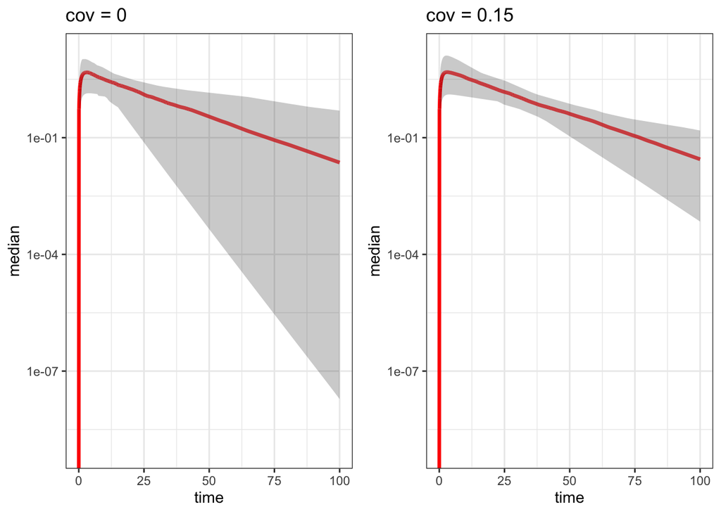

```r
pop_sim <- function(model){
  set.seed(0720)  #set a seed to facilitate the reproducibility of the simulation
  df <-
    model %>%
    ev(amt=100, cmt=1, time=0) %>%
    mrgsim(end=100, delta=0.1, nid=100, obsonly=TRUE) %>%
    as.data.frame()

  df <-
    df %>%
    group_by(time) %>%
    mutate(median = median(CP),
           upper = quantile(CP, 0.975),
           lower = quantile(CP, 0.025)) %>%
    ungroup()

  p <-
    df %>%
    ggplot()+
    geom_line(aes(x=time, y=median), color="red", size=1.2)+
    geom_ribbon(aes(x=time, ymin=lower, ymax=upper), fill="gray20", alpha=0.25)+
    scale_y_log10(limits = c(0.000000001, 15))+
    theme_bw()
}

p1 <- pop_sim(mod5) + ggtitle("cov = 0")
p2 <- pop_sim(mod6) + ggtitle("cov = 0.15")

ggarrange(p1, p2, ncol=2)
```

# 4. Useful Resources

- https://github.com/mrgsolve/learn
- GitHub site: https://github.com/metrumresearchgroup/mrgsolve
- mrgsolve website: https://mrgsolve.github.io
- User Guide: https://mrgsolve.github.io/user_guide